# Día 4: Variación de la longevidad en México

Autor/a

José Manuel Aburto y Ana Cristina Gómez Ugarte Valerio

Fecha de publicación

2026

En esta práctica aplicaremos el método integral lineal de Horiuchi et al. (2008) para descomponer cambios en la disparidad de la duración de la vida. Como extensión, compararemos los resultados con el método de reemplazo por pasos de Andreev, Shkolnikov y Begun (2002).

El ejemplo utiliza las tasas de mortalidad de hombres de México mayores de 15 años en 2005 y 2015. Los datos y el análisis proceden de Aburto y Beltrán-Sánchez (2019).

Trabajaremos en dos etapas:

1. Descomposición por edad.
2. Extensión por edad y causa de muerte.

## 1. Preparación

```r
library(DemoDecomp)
library(tidyverse)

load("variacion-longevidad-mexico-data.RData")
source("funciones-variacion-longevidad-mexico.R")
```

El conjunto de datos contiene tasas por todas las causas y nueve grupos de causas exhaustivos y mutuamente excluyentes.

```r
glimpse(data)
```

```
Rows: 220
Columns: 14
$ year     <int> 2005, 2005, 2005, 2005, 2005, 2005, 2005, 2005, 2005, 2005, 2…
$ age      <int> 0, 1, 2, 3, 4, 5, 6, 7, 8, 9, 10, 11, 12, 13, 14, 15, 16, 17,…
$ mx       <dbl> 0.0189706976, 0.0018979470, 0.0008808897, 0.0005872193, 0.000…
$ Cause_1  <dbl> 2.839166e-03, 6.888579e-04, 2.023529e-04, 9.300343e-05, 6.402…
$ Cause_2  <dbl> 3.377447e-05, 3.707395e-05, 5.436348e-05, 5.190889e-05, 3.793…
$ Cause_3  <dbl> 8.126982e-05, 3.229021e-05, 3.020193e-05, 3.028019e-05, 2.705…
$ Cause_4  <dbl> 1.174085e-02, 1.746063e-04, 8.154522e-05, 3.352449e-05, 2.916…
$ Cause_5  <dbl> 2.110904e-06, 2.391868e-06, 1.006731e-06, 3.244306e-06, 5.634…
$ Cause_6  <dbl> 3.588537e-05, 2.272274e-05, 1.812116e-05, 1.297722e-05, 1.032…
$ Cause_7  <dbl> 3.694083e-05, 9.806658e-05, 7.047118e-05, 7.245616e-05, 6.162…
$ Cause_8  <dbl> 0.0042006997, 0.0008419374, 0.0004228271, 0.0002898246, 0.000…
$ Cause_9  <dbl> 2.106171e-18, 0.000000e+00, 0.000000e+00, 6.519444e-20, 0.000…
$ ex       <dbl> 71.28505, 71.63812, 70.77327, 69.83520, 68.87592, 67.90771, 6…
$ e.dagger <dbl> 15.31042, 14.24554, 14.13733, 14.08783, 14.05537, 14.03011, 1…
```

## 2. Descomposición por edad

Construimos dos vectores con las tasas de mortalidad de 2005 y 2015 para las edades de 16 a 109 años.

```r
mx_2005 <- data |>
  filter(year == 2005, age > 15) |>
  pull(mx)

mx_2015 <- data |>
  filter(year == 2015, age > 15) |>
  pull(mx)

edades <- data |>
  filter(year == 2005, age > 15) |>
  pull(age)
```

Usaremos la disparidad de la duración de la vida, (e^), como indicador de variación. Esta medida resume los años de vida perdidos cuando ocurre una muerte.

```r
edagger.frommx
```

```
function (mx = mx, age, sex = NULL, ax = NULL)
{
    n <- c(diff(age))
    n <- c(n, n[length(n)])
    if (is.null(ax)) {
        ax <- 0.5 * n
        ax[length(ax)] <- if (mx[length(mx)] == 0)
            0.5
        else 1/mx[length(mx)]
        if (!is.null(sex)) {
            if (n[2] == 4) {
                if (sex == 1) {
                  if (mx[1] >= 0.107) {
                    ax[1] <- 0.33
                    ax[2] <- 1.352
                  }
                  else {
                    ax[1] <- 0.045 + 2.684 * mx[1]
                    ax[2] <- 1.651 - 2.816 * mx[1]
                  }
                }
                if (sex == 2) {
                  if (mx[1] >= 0.107) {
                    ax[1] <- 0.35
                    ax[2] <- 1.361
                  }
                  else {
                    ax[1] <- 0.053 + 2.8 * mx[1]
                    ax[2] <- 1.522 - 1.518 * mx[1]
                  }
                }
            }
        }
    }
    qx <- (n * mx)/(1 + (n - ax) * mx)
    qx <- c(qx[-(length(qx))], 1)
    qx[qx > 1] <- 1
    px <- 1 - qx
    lx <- cumprod(c(1, px))
    lx <- lx[1:length(age)]
    dx <- -diff(lx)
    dx[length(age)] <- lx[length(age)]
    lxpn <- c(lx[-1], 0)
    Lxpn <- n * lxpn + dx * ax
    Lx <- c(Lxpn[-length(Lxpn)], lx[length(lx)]/mx[length(mx)])
    Tx <- rev(cumsum(rev(Lx)))
    ex <- Tx/lx
    ex[is.na(ex)] <- 0
    ex[length(ex)] <- if (ex[length(ex)] == 0)
        0
    else ax[length(ex)]
    v <- (ax/n * c(ex[-1L], 0) + (1 - ax/n) * ex)
    v[length(ex)] <- ex[length(ex)]
    v <- dx * v
    e.dagger <- rev(cumsum(rev(v)))/lx
    return(e.dagger[1])
}
```

```r
horiuchi
```

```
function (func, pars1, pars2, N, ...)
{
    d <- pars2 - pars1
    n <- length(pars1)
    delta <- d/N
    grad <- matrix(rep(0.5:(N - 0.5)/N, n), byrow = TRUE, ncol = N)
    x <- pars1 + d * grad
    cc <- matrix(0, nrow = n, ncol = N)
    rownames(x) <- names(pars1)
    for (j in 1:N) {
        DD <- diag(delta/2)
        for (i in 1:n) {
            cc[i, j] <- func((x[, j] + DD[, i]), ...) - func((x[,
                j] - DD[, i]), ...)
        }
    }
    out <- rowSums(cc)
    names(out) <- names(pars1)
    out
}
<bytecode: 0x11da4fa88>
<environment: namespace:DemoDecomp>
```

La función `horiuchi()` devuelve las contribuciones de cada edad al cambio en (e^_{15}).

```r
resultados_horiuchi <- horiuchi(
  func = edagger.frommx,
  pars1 = mx_2005,
  pars2 = mx_2015,
  N = 50,
  age = edades
)
```

Comprobamos que la suma de las contribuciones reproduce la diferencia observada.

```r
diferencia_observada <- edagger.frommx(mx_2015, age = edades) -
  edagger.frommx(mx_2005, age = edades)
diferencia_descompuesta <- sum(resultados_horiuchi)
error_numerico <- diferencia_descompuesta - diferencia_observada

c(
  diferencia_observada = diferencia_observada,
  diferencia_descompuesta = diferencia_descompuesta,
  error_numerico = error_numerico
)
```

```
   diferencia_observada diferencia_descompuesta          error_numerico
          -1.439873e-01           -1.439873e-01            9.936372e-09
```

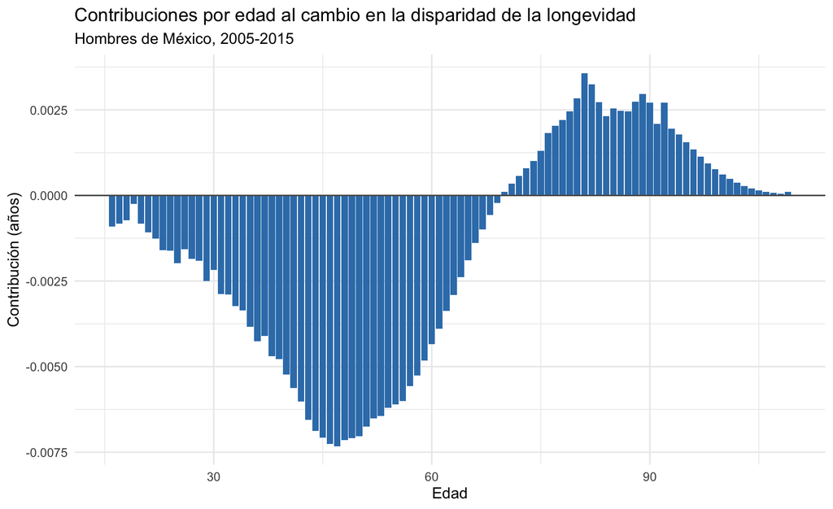

```r
datos_horiuchi <- tibble(
  edad = edades,
  contribucion = resultados_horiuchi
)

ggplot(datos_horiuchi, aes(x = edad, y = contribucion)) +
  geom_col(fill = "#377EB8") +
  geom_hline(yintercept = 0, colour = "grey35") +
  labs(
    title = "Contribuciones por edad al cambio en la disparidad de la longevidad",
    subtitle = "Hombres de México, 2005-2015",
    x = "Edad",
    y = "Contribución (años)"
  ) +
  theme_minimal(base_size = 12)
```

**Preguntas:**

- ¿Qué edades contribuyen a aumentar la disparidad?
- ¿Qué edades contribuyen a reducirla?
- ¿Cómo interpretarían una contribución negativa en edades jóvenes?

## 3. Comparación con el método de reemplazo por pasos

El método integral lineal no es la única estrategia de descomposición. El paquete **DemoDecomp** también permite aplicar un reemplazo por pasos.

```r
decomp_step
```

```
function (func, pars1, pars2, symmetrical = TRUE, direction = "up",
    ...)
{
    direction <- tolower(direction)
    stopifnot(direction %in% c("up", "down", "both"))
    up <- direction %in% c("up", "both")
    down <- direction %in% c("down", "both")
    N <- length(pars1)
    pars1Mat <- matrix(pars1, ncol = N + 1, nrow = N)
    pars2Mat <- matrix(pars2, ncol = N + 1, nrow = N)
    RM_1_2_up <- matrix(ncol = N + 1, nrow = N)
    RM_1_2_down <- RM_1_2_up
    RM_2_1_up <- RM_1_2_up
    RM_2_1_down <- RM_1_2_up
    r1ind <- lower.tri(pars1Mat, TRUE)
    r2ind <- upper.tri(pars1Mat)
    RM_1_2_up[r1ind] <- pars1Mat[r1ind]
    RM_1_2_up[r2ind] <- pars2Mat[r2ind]
    RM_1_2_down[r1ind[N:1, ]] <- pars1Mat[r1ind[N:1, ]]
    RM_1_2_down[r2ind[N:1, ]] <- pars2Mat[r2ind[N:1, ]]
    RM_2_1_up[r1ind] <- pars2Mat[r1ind]
    RM_2_1_up[r2ind] <- pars1Mat[r2ind]
    RM_2_1_down[r1ind[N:1, ]] <- pars2Mat[r1ind[N:1, ]]
    RM_2_1_down[r2ind[N:1, ]] <- pars1Mat[r2ind[N:1, ]]
    dec <- matrix(NA, nrow = N, ncol = 4)
    if (up) {
        dec[, 1] <- diff(apply(RM_1_2_up, 2, func, ...))
    }
    if (down) {
        dec[, 2] <- diff(apply(RM_1_2_down, 2, func, ...))
    }
    if (symmetrical) {
        if (up) {
            dec[, 3] <- -diff(apply(RM_2_1_up, 2, func, ...))
        }
        if (down) {
            dec[, 4] <- -diff(apply(RM_2_1_down, 2, func, ...))
        }
    }
    dec_avg <- rowMeans(dec, na.rm = TRUE)
    dec_avg
}
```

```r
resultados_pasos <- stepwise_replacement(
  edagger.frommx,
  pars1 = mx_2005,
  pars2 = mx_2015,
  age = edades
)

diferencia_descompuesta_pasos <- sum(resultados_pasos)
error_numerico_pasos <- diferencia_descompuesta_pasos -
  diferencia_observada

c(
  diferencia_observada = diferencia_observada,
  diferencia_descompuesta = diferencia_descompuesta_pasos,
  error_numerico = error_numerico_pasos
)
```

```
   diferencia_observada diferencia_descompuesta          error_numerico
             -0.1439873              -0.1439873               0.0000000
```

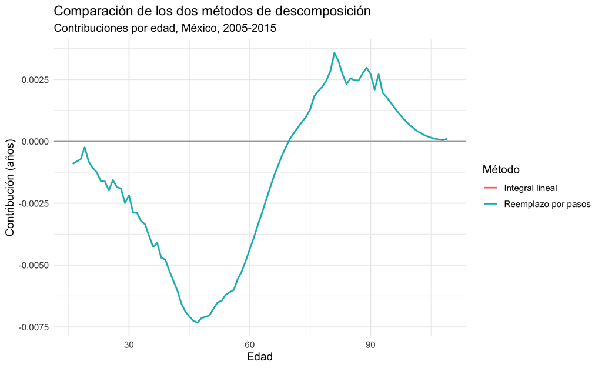

```r
comparacion_metodos <- tibble(
  edad = rep(edades, 2),
  contribucion = c(resultados_horiuchi, resultados_pasos),
  metodo = rep(
    c("Integral lineal", "Reemplazo por pasos"),
    each = length(edades)
  )
)

ggplot(
  comparacion_metodos,
  aes(x = edad, y = contribucion, colour = metodo)
) +
  geom_hline(yintercept = 0, colour = "grey70") +
  geom_line(linewidth = 0.8) +
  labs(
    title = "Comparación de los dos métodos de descomposición",
    subtitle = "Contribuciones por edad, México, 2005-2015",
    x = "Edad",
    y = "Contribución (años)",
    colour = "Método"
  ) +
  theme_minimal(base_size = 12)
```

```r
summary(resultados_horiuchi - resultados_pasos)
```

```
      Min.    1st Qu.     Median       Mean    3rd Qu.       Max.
-5.512e-07 -5.391e-08  4.258e-08  1.057e-10  1.660e-07  2.891e-07
```

**Pregunta:** ¿las diferencias entre los métodos cambian la interpretación sustantiva?

## 4. Extensión por edad y causa de muerte

Construimos matrices con edades en las filas y causas de muerte en las columnas.

```r
cod_2005 <- data |>
  filter(year == 2005, age > 15) |>
  select(Cause_1:Cause_9) |>
  as.matrix()

cod_2015 <- data |>
  filter(year == 2015, age > 15) |>
  select(Cause_1:Cause_9) |>
  as.matrix()
```

La función `edagger.frommxc()` transforma las tasas por edad y causa en tasas por todas las causas y calcula (e^).

```r
edagger.frommxc
```

```
function (mxcvec, age, sex = NULL, ax = NULL)
{
    dim(mxcvec) <- c(length(age), length(mxcvec)/length(age))
    mx <- rowSums(mxcvec)
    edagger.frommx(mx = mx, age = age, sex = sex, ax = ax)
}
```

```r
resultados_causa <- horiuchi(
  func = edagger.frommxc,
  pars1 = c(cod_2005),
  pars2 = c(cod_2015),
  N = 50,
  age = edades
)

dim(resultados_causa) <- dim(cod_2005)

diferencia_observada_causa <- edagger.frommxc(
  cod_2015,
  age = edades
) - edagger.frommxc(
  cod_2005,
  age = edades
)

diferencia_descompuesta_causa <- sum(resultados_causa)
error_numerico_causa <- diferencia_descompuesta_causa -
  diferencia_observada_causa

c(
  diferencia_observada = diferencia_observada_causa,
  diferencia_descompuesta = diferencia_descompuesta_causa,
  error_numerico = error_numerico_causa
)
```

```
   diferencia_observada diferencia_descompuesta          error_numerico
          -1.439873e-01           -1.439873e-01            9.925888e-09
```

```r
datos_causa <- data.frame(resultados_causa)
colnames(datos_causa) <- cause_names

datos_causa <- datos_causa |>
  mutate(edad = edades) |>
  pivot_longer(
    cols = -edad,
    names_to = "causa",
    values_to = "contribucion"
  )
```

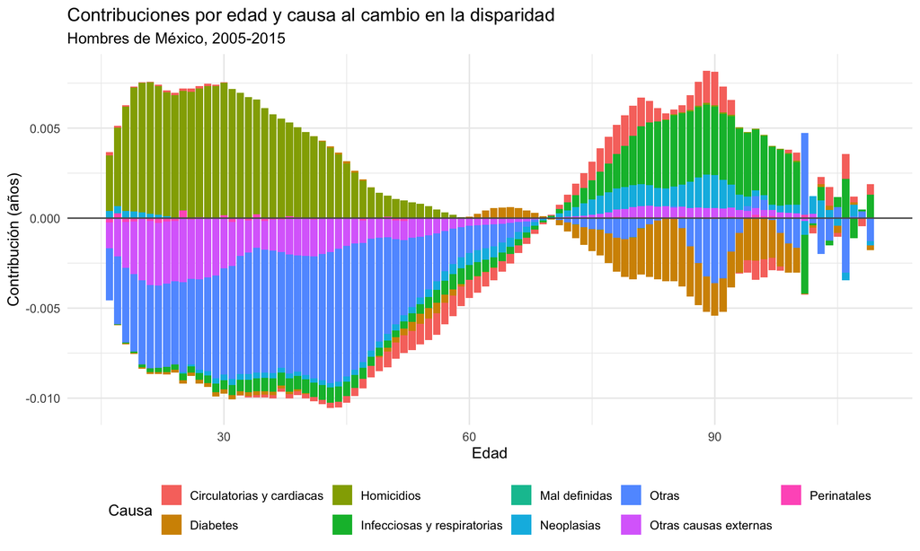

```r
ggplot(
  datos_causa,
  aes(x = edad, y = contribucion, fill = causa)
) +
  geom_col() +
  geom_hline(yintercept = 0, colour = "grey35") +
  labs(
    title = "Contribuciones por edad y causa al cambio en la disparidad",
    subtitle = "Hombres de México, 2005-2015",
    x = "Edad",
    y = "Contribución (años)",
    fill = "Causa"
  ) +
  theme_minimal(base_size = 12) +
  theme(legend.position = "bottom")
```

**Preguntas:**

- ¿Qué causas explican el cambio en la disparidad de la longevidad?
- ¿En qué edades se concentran sus contribuciones?
- ¿Qué combinación de edad y causa presenta la contribución más importante?

## 5. Grupos quinquenales de edad

Agreguemos las contribuciones del método integral lineal en grupos quinquenales.

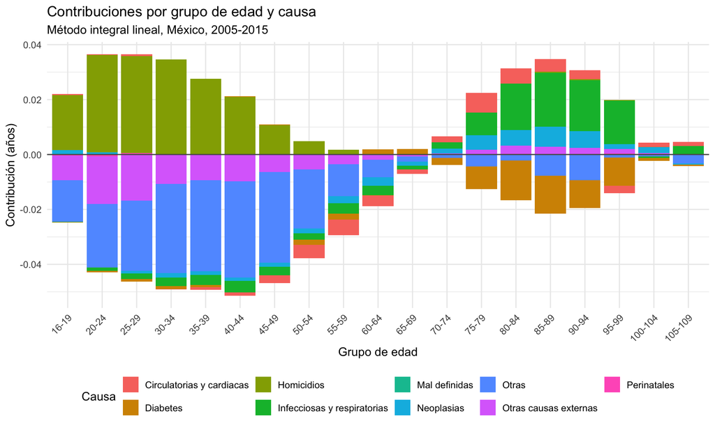

```r
datos_causa_quinquenales <- datos_causa |>
  mutate(
    grupo_edad = case_when(
      edad %in% 16:19 ~ "16-19",
      edad >= 20 ~ paste0(
        5 * floor(edad / 5),
        "-",
        5 * floor(edad / 5) + 4
      )
    )
  ) |>
  group_by(grupo_edad, causa) |>
  summarise(
    contribucion = sum(contribucion),
    .groups = "drop"
  ) |>
  mutate(
    limite_inferior = readr::parse_number(grupo_edad),
    grupo_edad = forcats::fct_reorder(grupo_edad, limite_inferior)
  )

ggplot(
  datos_causa_quinquenales,
  aes(x = grupo_edad, y = contribucion, fill = causa)
) +
  geom_col() +
  geom_hline(yintercept = 0, colour = "grey35") +
  labs(
    title = "Contribuciones por grupo de edad y causa",
    subtitle = "Método integral lineal, México, 2005-2015",
    x = "Grupo de edad",
    y = "Contribución (años)",
    fill = "Causa"
  ) +
  theme_minimal(base_size = 12) +
  theme(
    axis.text.x = element_text(angle = 45, hjust = 1),
    legend.position = "bottom"
  )
```

## 6. Extensión

Repitan la descomposición por edad y causa con el método de reemplazo por pasos. Comparen:

- el cambio total;
- las contribuciones por edad;
- las contribuciones por causa; y
- las diferencias entre ambos métodos.